# Cluster K-Means: ecv_cluster

# Modelo

## Formulación

**IMPORTANTE**:

- Ver que no hay ningún **NA** en el dataset.
- El **escalado** es un paso esencial en la fase de preprocesamiento de datos para los algoritmos de agrupación. Garantiza que cada característica contribuya por igual al proceso de decisión del algoritmo, lo que lleva a resultados de agrupación más precisos e interpretables.

```r
ifelse(sum(is.na(data)) == 0, print("There is no NA in the dataset."), print("There is some NA in the dataset."))
```

```
## [1] "There is no NA in the dataset."
```

```
## [1] "There is no NA in the dataset."
```

Si quueremos que el código sea reproducible, es necesario fijar semilla (función `set.seed(n)`) ya que el algoritmo *k-means* elige los centroides iniciales aleatoriamente.

```r
# Preparación de los datos
resultado <- datos[, c("taspobex", "tascar")]

resultado <- scale(resultado) # scaling/standardizing
rownames(resultado) <- datos$CCAA # Para que nos salgan luego los nombres
comunidades <- datos$CCAA


# K-MEANS algortihm
set.seed(785248) # reproducibilidad
k1 <- kmeans(resultado, centers = 3, nstart = 25)
k1
```

```
## K-means clustering with 3 clusters of sizes 11, 3, 5
##
## Cluster means:
##     taspobex      tascar
## 1 -0.7548531 -0.51757600
## 2  1.3941669  1.99603588
## 3  0.8241767 -0.05895433
##
## Clustering vector:
##                   Andalucía                      Aragón
##                           3                           1
##     Asturias, Principado de              Balears, Illes
##                           1                           1
##                    Canarias                   Cantabria
##                           2                           1
##             Castilla y León        Castilla - La Mancha
##                           1                           3
##                    Cataluña        Comunitat Valenciana
##                           1                           3
##                 Extremadura                     Galicia
##                           3                           1
##        Madrid, Comunidad de           Murcia, Región de
##                           1                           3
## Navarra, Comunidad Foral de                  País Vasco
##                           1                           1
##                   Rioja, La                       Ceuta
##                           1                           2
##                     Melilla
##                           2
##
## Within cluster sum of squares by cluster:
## [1] 2.413697 1.571024 1.603415
##  (between_SS / total_SS =  84.5 %)
##
## Available components:
##
## [1] "cluster"      "centers"      "totss"        "withinss"     "tot.withinss"
## [6] "betweenss"    "size"         "iter"         "ifault"
```

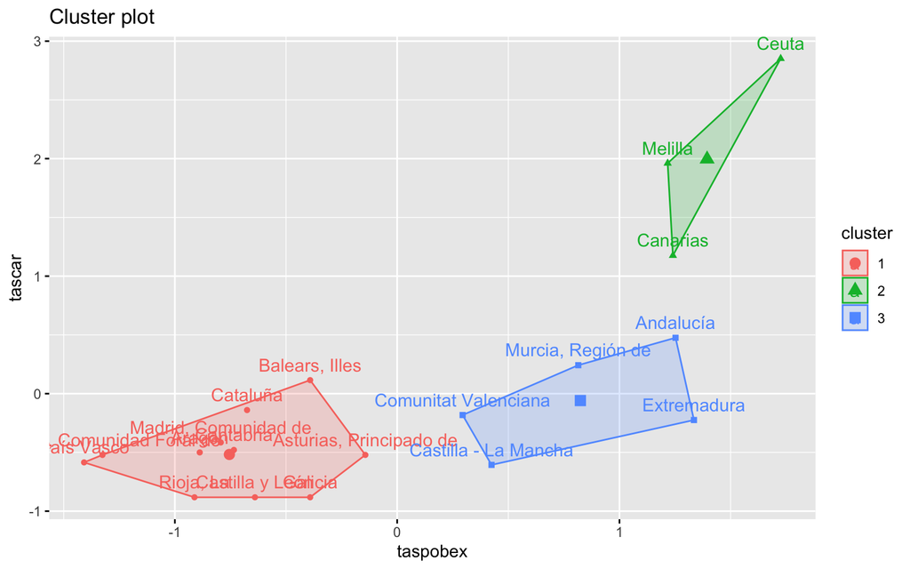

```r
fviz_cluster(k1, data = resultado) # plot
```

Notar que podemos mostrar los datos originales junto al cluster al que pertenecen.

```r
# Mostrar Clusters
datos %>%
  mutate(cluster = k1$cluster) %>%
  select("CCAA", "taspobex", "tascar","cluster")
```

```
## # A tibble: 19 × 4
##    CCAA                        taspobex tascar cluster
##    <chr>                          <dbl>  <dbl>   <int>
##  1 Andalucía                       38.4   10.2       3
##  2 Aragón                          20.3    5.6       1
##  3 Asturias, Principado de         26.6    5.5       1
##  4 Balears, Illes                  24.5    8.5       1
##  5 Canarias                        38.3   13.5       2
##  6 Cantabria                       21.6    5.7       1
##  7 Castilla y León                 22.4    3.8       1
##  8 Castilla - La Mancha            31.4    5.1       3
##  9 Cataluña                        22.1    7.3       1
## 10 Comunitat Valenciana            30.3    7.1       3
## 11 Extremadura                     39.1    6.9       3
## 12 Galicia                         24.5    3.8       1
## 13 Madrid, Comunidad de            21.1    6         1
## 14 Murcia, Región de               34.7    9.1       3
## 15 Navarra, Comunidad Foral de     16.6    5.5       1
## 16 País Vasco                      15.9    5.2       1
## 17 Rioja, La                       20.1    3.8       1
## 18 Ceuta                           42.4   21.4       2
## 19 Melilla                         38.1   17.2       2
```

# Número Clusters Óptimo

Encontrar el número óptimo de clusters implica identificar la cantidad ideal de grupos en los que se pueden dividir los datos de manera significativa y coherente. Es crucial porque determina la calidad y utilidad de los resultados del análisis de agrupamiento.

## Método Elbrow

Una de las formas comunes de determinar este número es a través del método del **codo** o **elbow** en inglés. Este método busca identificar el punto donde la adición de más clusters ya no proporciona un beneficio significativo en la varianza explicada o la cohesión dentro de los grupos.

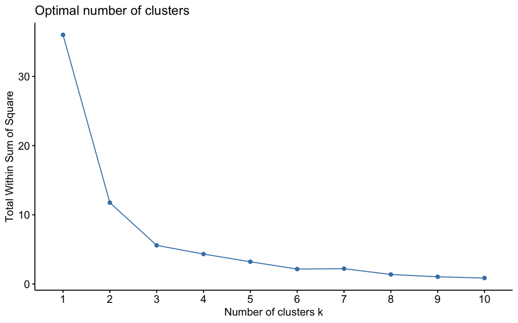

```r
#  Método Elbrow
set.seed(785248)
factoextra::fviz_nbclust(resultado, kmeans, method = "wss",print.summary = TRUE)
```

El número óptimo de k parece ser 3 que es donde más se reduce la pendiente y la variabilidad explicada no parece disminuir de forma tan rápida. De todos modos, también podría parecer razonable tomar el 2 o 4. Es por ello que vamos a usar algún método adicional.

## Método Silhouette

El **método Silhouette** es una técnica utilizada para determinar la calidad de la agrupación en un conjunto de datos. Consiste en calcular el valor de la silueta para cada punto de datos, que mide qué tan similar es un punto a su propio grupo (cohesión) en comparación con otros grupos vecinos (separación).

El proceso implica:

1. **Cálculo de la silueta individual**: Para cada punto de datos, se calcula la silueta, que es la diferencia entre la distancia media intra-cluster (distancia al resto de puntos en su mismo grupo) y la distancia media al cluster más cercano (distancia a los puntos del grupo más próximo, excluyendo el propio grupo).
2. **Valor de la silueta global**: Se obtiene el promedio de las siluetas individuales de todos los puntos de datos en el conjunto. Contra más cercano a 1, mejor formado estará el clsuter.

La siguiente función generará un gráfico que muestra los valores de Silhouette en función del número de clusters. El número óptimo de clusters es típicamente aquel que maximiza el valor de Silhouette, representando una mejor cohesión intra-cluster y separación inter-cluster.

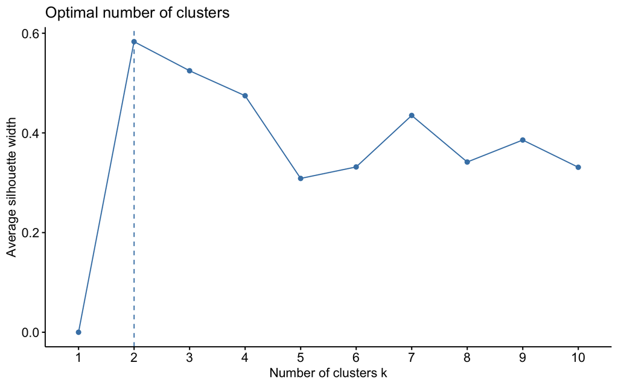

```r
#  Método Silhouette
set.seed(785248)
factoextra::fviz_nbclust(resultado, kmeans, method = "silhouette")
```

**NOTA**: Ahora podríamos repetir el estudio anterior con el número de clusters igual a 2 e intentar analizar de neuvo los resultados.

```r
# K-MEANS algortihm
set.seed(785248) # reproducibilidad
k1 <- kmeans(resultado, centers = 2, nstart = 25)
k1
```

```
## K-means clustering with 2 clusters of sizes 13, 6
##
## Cluster means:
##     taspobex     tascar
## 1 -0.5834244 -0.4985867
## 2  1.2640861  1.0802711
##
## Clustering vector:
##                   Andalucía                      Aragón
##                           2                           1
##     Asturias, Principado de              Balears, Illes
##                           1                           1
##                    Canarias                   Cantabria
##                           2                           1
##             Castilla y León        Castilla - La Mancha
##                           1                           1
##                    Cataluña        Comunitat Valenciana
##                           1                           1
##                 Extremadura                     Galicia
##                           2                           1
##        Madrid, Comunidad de           Murcia, Región de
##                           1                           2
## Navarra, Comunidad Foral de                  País Vasco
##                           1                           1
##                   Rioja, La                       Ceuta
##                           1                           2
##                     Melilla
##                           2
##
## Within cluster sum of squares by cluster:
## [1] 4.639180 7.114779
##  (between_SS / total_SS =  67.4 %)
##
## Available components:
##
## [1] "cluster"      "centers"      "totss"        "withinss"     "tot.withinss"
## [6] "betweenss"    "size"         "iter"         "ifault"
```

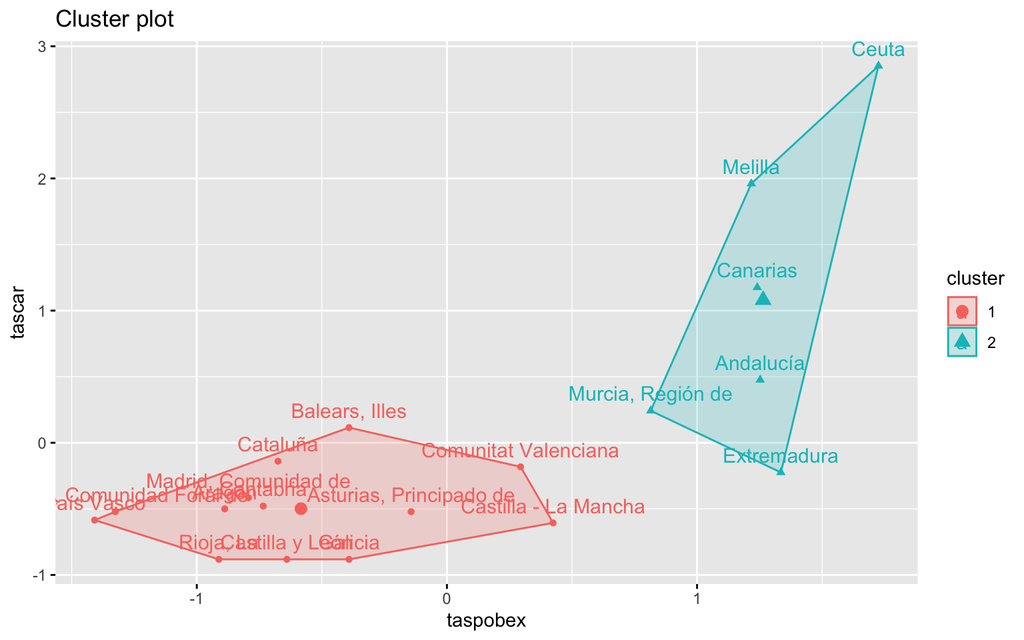

```r
fviz_cluster(k1, data = resultado) # plot
```

# Conclusiones

Aquí se han explicado los supuestos del cluster K-MEANS con un dataset en el que se han creado clusters de CCAA según tasa de riesgo de pobreza y la carencia material. La evidencia nos ha mostrado que se tiende a grupar las comunidades con incidencias más altas por un lado y más bajas por otro.

[^1]: EDA viene del Inglés *Exploratory Data Analysis* y son los pasos relativos en los que se exploran las variables para tener una idea de que forma toma el dataset.